# Análisis de secuencias PacBio con DADA2

## Instalando y llamando la paquetería

Primero se procede a instalar la paquetería para la versión de RStudio correspondiente.

```r
if (!requireNamespace("BiocManager", quietly = TRUE))
    install.packages("BiocManager")
BiocManager::install("dada2", version = "3.20") #Ajustar versión en caso de que haya sido actualizada
```

## Preparación de librerías

Para comenzar a trabajar con las muestras que se pretenden analizar, se debe mandar a llamar las librerías como se presenta a continuación.

```r
library(dada2)
library(Biostrings)
library(ggplot2)
library(reshape2)
```

Se define una variable con la ruta de destino para acceder a las muestras. Además se definen dos variables correspondientes a los primers en ambas direcciones (los utilizados por consenso).

```r
#Cargar la ruta donde tengas tus muestras
path <- "/Users/adriantorres/Desktop/UNIVERSIDAD/SERVICIO/SECUENCIAS Pac_Bio"
#Estableces esa misma ruta como tu directorio para que todos los archivos sean creados dentro de la misma carpeta
setwd <- "/Users/adriantorres/Desktop/UNIVERSIDAD/SERVICIO/SECUENCIAS Pac_Bio"
muestras <- sort(list.files(path,
                            pattern=".hifi_reads.fastq.gz",
                            full.names = TRUE)) #Adecuar el patrón que sigan los nombres de archivos
F27 <- "AGRGTTYGATYMTGGCTCAG"
R1492 <- "RGYTACCTTGTTACGACTT"
rc <- dada2:::rc
```

## Remover primers

Se procede a recortar los primers de todas las secuencias en nuestra muestra, para después orientarlas correctamente.

```r
nop <- file.path(path, "noprimers", basename(muestras))
prim <- removePrimers(muestras, nop, primer.fwd=F27, primer.rev=dada2:::rc(R1492), orient=TRUE, verbose=TRUE)
```

```
## 66058 sequences out of 135531 are being reverse-complemented.
```

```
## 70288 sequences out of 144461 are being reverse-complemented.
```

## Inspeccionar perfiles de calidad en las lecturas

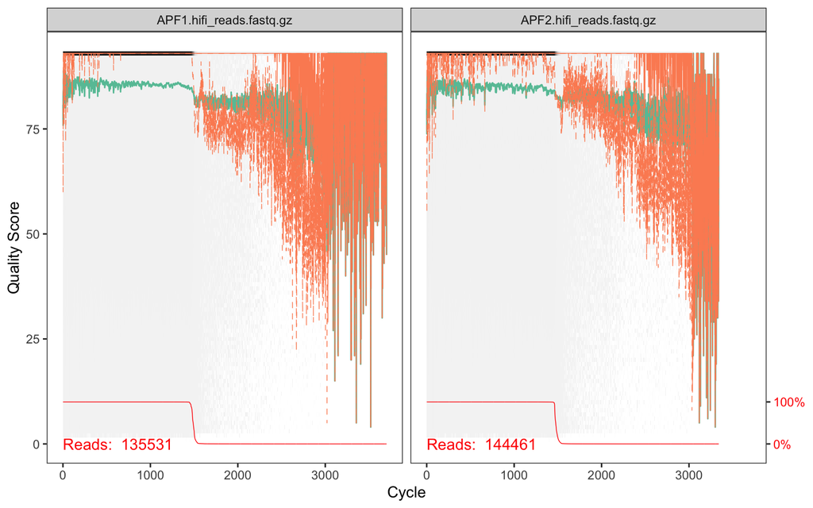

```r
plotQualityProfile(muestras[1:2])
```

```r
  #En la figura, Reads representa el número n de muestras leídas, por default la función usa 500,000 muestras, se puede modificar agregando a la línea de código n= número deseado. Un ejemplo a continuación
  # Puedes correr plotQualityProfile(muestras, aggregate = TRUE) para obtener un promedio
```

[output not shown]

## Filtrado de secuencias

Posteriormente se procede a inspeccionar las frecuencias en los tamaños de las secuencias.

[figure not shown]

```r
hist(nchar(getSequences(nop)), 100)
```

```r
filt <- file.path(path, "noprimers", "filtered", basename(muestras))
track <- filterAndTrim(nop, filt,
                       minQ=3, minLen=1000,
                       maxLen=1600, maxN=0,
                       rm.phix=FALSE, maxEE=2,
                       verbose=TRUE)
head(track)
```

```
##                          reads.in reads.out
## APF1.hifi_reads.fastq.gz   124388     81065
## APF2.hifi_reads.fastq.gz   133471     81486
```

> <sub>Para cada muestra a analizar, revisar los histogramas y ajustar los valores de *minLen* y *maxLen* de acuerdo a ellos.</sub>

## Derreplicación

Se realiza una derreplicación para eliminar comparaciones redundantes y aligerar el trabajo computacional.

```r
drp <- derepFastq(filt, verbose=TRUE)
```

## Tasa de errores

Se corre el modelo para aprendizaje de errores en la secuenciación de nuestra muestra.

```r
err <- learnErrors(drp, BAND_SIZE=8,
                   multithread=TRUE,
                   verbose = TRUE,
                   errorEstimationFunction=dada2:::PacBioErrfun)
```

```
## 117341196 total bases in 81065 reads from 1 samples will be used for learning the error rates.
## Initializing error rates to maximum possible estimate.
## selfConsist step 1 .
##    selfConsist step 2
##    selfConsist step 3
##    selfConsist step 4
##    selfConsist step 5
## Convergence after  5  rounds.
```

Se inspeccionan la tendencia de los errores cometidos en la secuenciación. (Observar que los puntos y la línea de resultados esperados no estén alejados.)

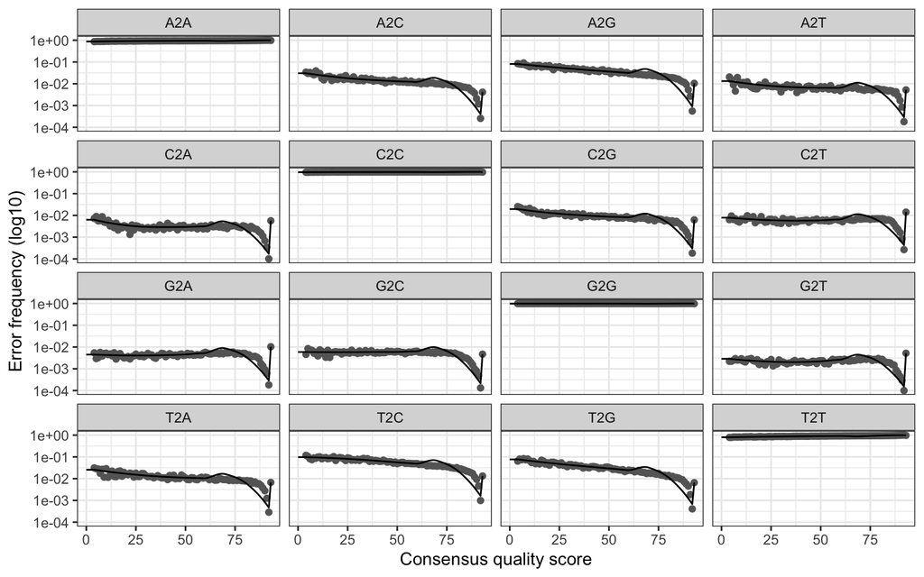

```r
plotErrors(err)
```

## Denoising

Procede a realizar el *denoising* para dar una reconstrucción lo más exacta posible de las variantes de la secuencia de amplicones.

```r
dd <- dada(drp, err=err, BAND_SIZE=8, multithread=TRUE)
dd
```

Con las siguientes líneas de código se puede visualizar cuantas secuencias han sido filtradas con el procesamiento.

```r
cbind(ccs=prim[,1], primers=prim[,2], filtered=track[[2]], denoised=sum(dd$denoised))
```

[output not shown]

## Taxonomía y quimeras

Primero se crea una tabla con las secuencias obtenidas

```r
seqtab<- makeSequenceTable(dd)
```

Analizar si dentro de la muestra hay químeras.

```r
bim <- isBimeraDenovo(dd, minFodParentOverAbundance=3.5, multithread=TRUE)
table(bim)
```

Con el procesamiento previo se asegura la eliminación de los errores de sustitución o de indel, pero las químeras persisten. Para eliminarlas la paquetería contiene funciones integradas que son de utilidad.

```r
seqtab.nochim <- removeBimeraDenovo(dd, method="consensus", multithread=TRUE, verbose=TRUE)
dim(seqtab.nochim)
sum(seqtab.nochim)/sum(seqtab)
```

> <sub>Si la mayoría de las secuencias son eliminadas tras remover las químeras el procesamiento previo debe ser revisado.</sub>

## Asignar taxonomía

Se le puede asignar la taxonomía a las diferentes secuencias de la muestra utilizando un archivo de referencia.

```r
#Ajustar la ruta donde se encuentran los archivos de referencia
tax <- assignTaxonomy(seqtab.nochim, "/Users/adriantorres/Desktop/UNIVERSIDAD/SERVICIO/silva_nr99_v138.1_train_set.fa", multithread=TRUE)

#Si quieres ser más específico puedes añadir las especies (opcional)
tax <- addSpecies(tax, "/Users/adriantorres/Desktop/UNIVERSIDAD/SERVICIO/silva_species_assignment_v138.1.fa")
```

> <sub>No olvidar modificar las rutas de los archivos acorde a las de su equipo computacional</sub>

## Exportar secuencias

Por último se procede a guardar las secuencias y las tablas para futuro análisis y procesamiento de datos.

```r
#Primero se procede a darles nombres reconocibles
asv_seqs <- colnames(seqtab.nochim)
asv_headers <- vector(dim(seqtab.nochim)[2], mode="character")
for (i in 1:dim(seqtab.nochim)[2]) {
  asv_headers[i] <- paste(">ASV", i, sep="_")
}
#Establecer la carpeta donde se van a guardar
path2<-file.path(path, "Tablas")
dir.create(path2)
#Archivo fasta de ASVs
asv_fasta <- c(rbind(asv_headers, asv_seqs))
write(asv_fasta, file.path(path2, "PacBioASVs.fa"))
#Archivo csv de abundancias
asv_tab <- t(seqtab.nochim)
row.names(asv_tab) <- sub(">", "", asv_headers)
write.table(asv_tab, file.path(path2,"PacBioASVs_counts_silva.csv"), sep="\t", quote=F, col.names=NA)
#Archivo csv de taxonomias
asv_tax <- taxa
row.names(asv_tax) <- sub(">", "", asv_headers)
write.table(asv_tax, file.path(path2,"PacBioASVs_taxonomy_silva.csv"), sep="\t", quote=F, col.names=NA)
#Archivo csv de taxones y abundancias
asv_total <- merge(asv_tab,asv_tax,by="row.names",all.x=TRUE)
write.table(asv_total, file.path(path2,"PacBioASVs_total_silva.csv"), sep="\t", quote=F, col.names=NA)
```

## Guardar objetos RDS

```r
#Por último se guardan en formato de datos para ser abiertos en otra sesión
saveRDS(dd, file.path(path2, "muestras_dd.rds"))
saveRDS(tax, file.path(path2, "muestras_tax_Silva128.rds"))
```